# Risk Factor Analysis

## Outcome Variable

**Outcome Variable:** dead

## Predictor Variables

**Intervention Variable:** ever_co06

**Adjustment Set:**

- sex
- arm
- enstunt
- month
- brthmon
- vagbrth
- impfloor
- earlybf
- hfoodsec
- hhwealth_quart
- W_birthwt
- W_birthlen
- W_mage
- W_mhtcm
- W_meducyrs
- W_feducyrs
- W_nrooms
- W_parity
- impsan
- safeh20
- predexfd6
- delta_month
- delta_brthmon
- delta_vagbrth
- delta_impfloor
- delta_earlybf
- delta_hfoodsec
- delta_hhwealth_quart
- delta_W_birthwt
- delta_W_birthlen
- delta_W_mage
- delta_W_mhtcm
- delta_W_meducyrs
- delta_W_feducyrs
- delta_W_nrooms
- delta_W_parity
- delta_impsan
- delta_safeh20
- delta_predexfd6

## Stratifying Variables

The analysis was stratified on these variable(s):

- studyid
- country

## Data Summary

| studyid | country | ever_co06 | dead | n_cell | n |
| --- | --- | --- | --- | --- | --- |
| ki0047075b-MAL-ED | BANGLADESH | 0 | 0 | 231 | 239 |
| ki0047075b-MAL-ED | BANGLADESH | 0 | 1 | 0 | 239 |
| ki0047075b-MAL-ED | BANGLADESH | 1 | 0 | 8 | 239 |
| ki0047075b-MAL-ED | BANGLADESH | 1 | 1 | 0 | 239 |
| ki0047075b-MAL-ED | INDIA | 0 | 0 | 218 | 235 |
| ki0047075b-MAL-ED | INDIA | 0 | 1 | 0 | 235 |
| ki0047075b-MAL-ED | INDIA | 1 | 0 | 17 | 235 |
| ki0047075b-MAL-ED | INDIA | 1 | 1 | 0 | 235 |
| ki0047075b-MAL-ED | PERU | 0 | 0 | 268 | 270 |
| ki0047075b-MAL-ED | PERU | 0 | 1 | 1 | 270 |
| ki0047075b-MAL-ED | PERU | 1 | 0 | 1 | 270 |
| ki0047075b-MAL-ED | PERU | 1 | 1 | 0 | 270 |
| ki0047075b-MAL-ED | SOUTH AFRICA | 0 | 0 | 255 | 259 |
| ki0047075b-MAL-ED | SOUTH AFRICA | 0 | 1 | 0 | 259 |
| ki0047075b-MAL-ED | SOUTH AFRICA | 1 | 0 | 4 | 259 |
| ki0047075b-MAL-ED | SOUTH AFRICA | 1 | 1 | 0 | 259 |
| ki0047075b-MAL-ED | TANZANIA, UNITED REPUBLIC OF | 0 | 0 | 241 | 245 |
| ki0047075b-MAL-ED | TANZANIA, UNITED REPUBLIC OF | 0 | 1 | 0 | 245 |
| ki0047075b-MAL-ED | TANZANIA, UNITED REPUBLIC OF | 1 | 0 | 4 | 245 |
| ki0047075b-MAL-ED | TANZANIA, UNITED REPUBLIC OF | 1 | 1 | 0 | 245 |
| ki1000304-VITAMIN-A | INDIA | 0 | 0 | 2591 | 2710 |
| ki1000304-VITAMIN-A | INDIA | 0 | 1 | 12 | 2710 |
| ki1000304-VITAMIN-A | INDIA | 1 | 0 | 106 | 2710 |
| ki1000304-VITAMIN-A | INDIA | 1 | 1 | 1 | 2710 |
| ki1000304b-SAS-CompFeed | INDIA | 0 | 0 | 1279 | 1380 |
| ki1000304b-SAS-CompFeed | INDIA | 0 | 1 | 6 | 1380 |
| ki1000304b-SAS-CompFeed | INDIA | 1 | 0 | 90 | 1380 |
| ki1000304b-SAS-CompFeed | INDIA | 1 | 1 | 5 | 1380 |
| ki1000304b-SAS-FoodSuppl | INDIA | 0 | 0 | 366 | 399 |
| ki1000304b-SAS-FoodSuppl | INDIA | 0 | 1 | 1 | 399 |
| ki1000304b-SAS-FoodSuppl | INDIA | 1 | 0 | 29 | 399 |
| ki1000304b-SAS-FoodSuppl | INDIA | 1 | 1 | 3 | 399 |
| ki1017093b-PROVIDE | BANGLADESH | 0 | 0 | 586 | 613 |
| ki1017093b-PROVIDE | BANGLADESH | 0 | 1 | 0 | 613 |
| ki1017093b-PROVIDE | BANGLADESH | 1 | 0 | 27 | 613 |
| ki1017093b-PROVIDE | BANGLADESH | 1 | 1 | 0 | 613 |
| ki1066203-TanzaniaChild2 | TANZANIA, UNITED REPUBLIC OF | 0 | 0 | 1999 | 2017 |
| ki1066203-TanzaniaChild2 | TANZANIA, UNITED REPUBLIC OF | 0 | 1 | 1 | 2017 |
| ki1066203-TanzaniaChild2 | TANZANIA, UNITED REPUBLIC OF | 1 | 0 | 17 | 2017 |
| ki1066203-TanzaniaChild2 | TANZANIA, UNITED REPUBLIC OF | 1 | 1 | 0 | 2017 |
| ki1101329-Keneba | GAMBIA | 0 | 0 | 2143 | 2227 |
| ki1101329-Keneba | GAMBIA | 0 | 1 | 25 | 2227 |
| ki1101329-Keneba | GAMBIA | 1 | 0 | 53 | 2227 |
| ki1101329-Keneba | GAMBIA | 1 | 1 | 6 | 2227 |
| ki1112895-Burkina Faso Zn | BURKINA FASO | 0 | 0 | 41 | 43 |
| ki1112895-Burkina Faso Zn | BURKINA FASO | 0 | 1 | 0 | 43 |
| ki1112895-Burkina Faso Zn | BURKINA FASO | 1 | 0 | 2 | 43 |
| ki1112895-Burkina Faso Zn | BURKINA FASO | 1 | 1 | 0 | 43 |
| ki1113344-GMS-Nepal | NEPAL | 0 | 0 | 565 | 590 |
| ki1113344-GMS-Nepal | NEPAL | 0 | 1 | 1 | 590 |
| ki1113344-GMS-Nepal | NEPAL | 1 | 0 | 23 | 590 |
| ki1113344-GMS-Nepal | NEPAL | 1 | 1 | 1 | 590 |
| ki1126311-ZVITAMBO | ZIMBABWE | 0 | 0 | 10200 | 10590 |
| ki1126311-ZVITAMBO | ZIMBABWE | 0 | 1 | 284 | 10590 |
| ki1126311-ZVITAMBO | ZIMBABWE | 1 | 0 | 97 | 10590 |
| ki1126311-ZVITAMBO | ZIMBABWE | 1 | 1 | 9 | 10590 |
| ki1148112-iLiNS-DOSE | MALAWI | 0 | 0 | 981 | 993 |
| ki1148112-iLiNS-DOSE | MALAWI | 0 | 1 | 5 | 993 |
| ki1148112-iLiNS-DOSE | MALAWI | 1 | 0 | 6 | 993 |
| ki1148112-iLiNS-DOSE | MALAWI | 1 | 1 | 1 | 993 |
| ki1148112-iLiNS-DYAD-M | MALAWI | 0 | 0 | 1058 | 1081 |
| ki1148112-iLiNS-DYAD-M | MALAWI | 0 | 1 | 16 | 1081 |
| ki1148112-iLiNS-DYAD-M | MALAWI | 1 | 0 | 7 | 1081 |
| ki1148112-iLiNS-DYAD-M | MALAWI | 1 | 1 | 0 | 1081 |
| kiGH5241-JiVitA-3 | BANGLADESH | 0 | 0 | 16446 | 17159 |
| kiGH5241-JiVitA-3 | BANGLADESH | 0 | 1 | 139 | 17159 |
| kiGH5241-JiVitA-3 | BANGLADESH | 1 | 0 | 562 | 17159 |
| kiGH5241-JiVitA-3 | BANGLADESH | 1 | 1 | 12 | 17159 |
| kiGH5241-JiVitA-4 | BANGLADESH | 0 | 0 | 4906 | 5078 |
| kiGH5241-JiVitA-4 | BANGLADESH | 0 | 1 | 38 | 5078 |
| kiGH5241-JiVitA-4 | BANGLADESH | 1 | 0 | 132 | 5078 |
| kiGH5241-JiVitA-4 | BANGLADESH | 1 | 1 | 2 | 5078 |

The following strata were considered:

- studyid: ki0047075b-MAL-ED, country: BANGLADESH
- studyid: ki0047075b-MAL-ED, country: INDIA
- studyid: ki0047075b-MAL-ED, country: PERU
- studyid: ki0047075b-MAL-ED, country: SOUTH AFRICA
- studyid: ki0047075b-MAL-ED, country: TANZANIA, UNITED REPUBLIC OF
- studyid: ki1000304-VITAMIN-A, country: INDIA
- studyid: ki1000304b-SAS-CompFeed, country: INDIA
- studyid: ki1000304b-SAS-FoodSuppl, country: INDIA
- studyid: ki1017093b-PROVIDE, country: BANGLADESH
- studyid: ki1066203-TanzaniaChild2, country: TANZANIA, UNITED REPUBLIC OF
- studyid: ki1101329-Keneba, country: GAMBIA
- studyid: ki1112895-Burkina Faso Zn, country: BURKINA FASO
- studyid: ki1113344-GMS-Nepal, country: NEPAL
- studyid: ki1126311-ZVITAMBO, country: ZIMBABWE
- studyid: ki1148112-iLiNS-DOSE, country: MALAWI
- studyid: ki1148112-iLiNS-DYAD-M, country: MALAWI
- studyid: kiGH5241-JiVitA-3, country: BANGLADESH
- studyid: kiGH5241-JiVitA-4, country: BANGLADESH

### Dropped Strata

Some strata were dropped due to rare outcomes:

- studyid: ki0047075b-MAL-ED, country: BANGLADESH
- studyid: ki0047075b-MAL-ED, country: INDIA
- studyid: ki0047075b-MAL-ED, country: PERU
- studyid: ki0047075b-MAL-ED, country: SOUTH AFRICA
- studyid: ki0047075b-MAL-ED, country: TANZANIA, UNITED REPUBLIC OF
- studyid: ki1000304-VITAMIN-A, country: INDIA
- studyid: ki1000304b-SAS-FoodSuppl, country: INDIA
- studyid: ki1017093b-PROVIDE, country: BANGLADESH
- studyid: ki1066203-TanzaniaChild2, country: TANZANIA, UNITED REPUBLIC OF
- studyid: ki1112895-Burkina Faso Zn, country: BURKINA FASO
- studyid: ki1113344-GMS-Nepal, country: NEPAL
- studyid: ki1148112-iLiNS-DOSE, country: MALAWI
- studyid: ki1148112-iLiNS-DYAD-M, country: MALAWI
- studyid: kiGH5241-JiVitA-4, country: BANGLADESH

## Methods Detail

We’re interested in the causal parameters $E[Y_a]$ for all values of $a \in \mathcal{A}$. These parameters represent the mean outcome if, possibly contrary to fact, we intervened to set all units to have $A=a$. Under the randomization and positivity assumptions, these are identified by the statistical parameters $\psi_a=E_W[E_{Y|A,W}(Y|A=a,W)]$. In addition, we’re interested in the mean of $Y$, $E[Y]$ under no intervention (the observed mean). We will estimate these parameters by using SuperLearner to fit the relevant likelihood factors – $E_{Y|A,W}(Y|A=a,W)$ and $p(A=a|W)$, and then updating our likelihood fit using a joint TMLE.

For unadjusted analyses ($W=\{\}$), initial likelihoods were estimated using Lrnr_glm to estimate the simple $E(Y|A)$ and Lrnr_mean to estimate $p(A)$. For adjusted analyses, a small library containing Lrnr_glmnet, Lrnr_xgboost, and Lrnr_mean was used.

Having estimated these parameters, we will then use the delta method to estimate relative risks and attributable risks relative to a prespecified baseline level of $A$.

# Results Detail

## Results Plots

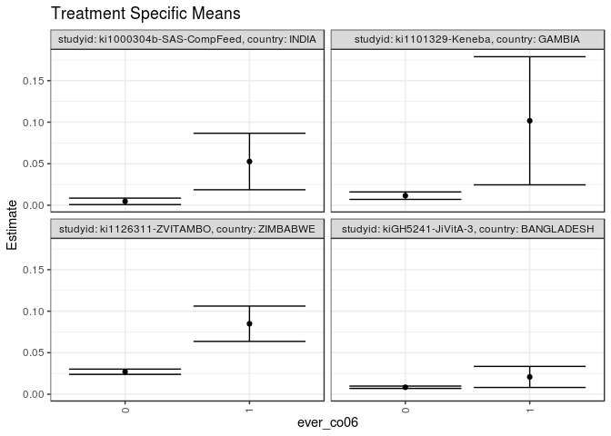

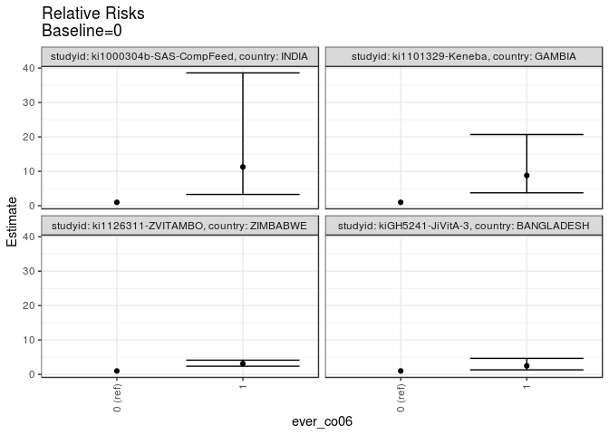

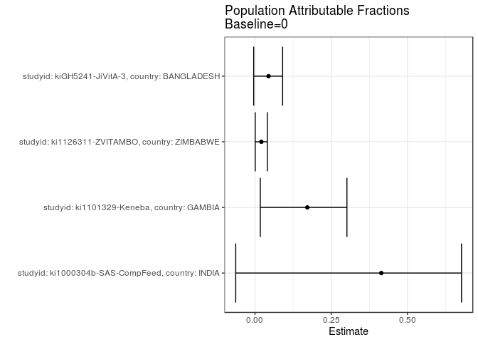

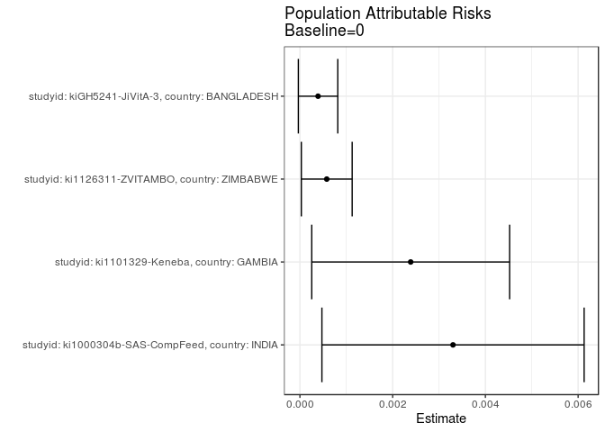

## Results Table

### Parameter: TSM

| studyid | country | intervention_level | baseline_level | estimate | ci_lower | ci_upper |
| --- | --- | --- | --- | --- | --- | --- |
| ki1000304b-SAS-CompFeed | INDIA | 0 | NA | 0.0046693 | 0.0007540 | 0.0085846 |
| ki1000304b-SAS-CompFeed | INDIA | 1 | NA | 0.0526316 | 0.0186106 | 0.0866525 |
| ki1101329-Keneba | GAMBIA | 0 | NA | 0.0115314 | 0.0070363 | 0.0160264 |
| ki1101329-Keneba | GAMBIA | 1 | NA | 0.1016949 | 0.0245546 | 0.1788352 |
| ki1126311-ZVITAMBO | ZIMBABWE | 0 | NA | 0.0270889 | 0.0239334 | 0.0302444 |
| ki1126311-ZVITAMBO | ZIMBABWE | 1 | NA | 0.0849057 | 0.0636592 | 0.1061521 |
| kiGH5241-JiVitA-3 | BANGLADESH | 0 | NA | 0.0084088 | 0.0070085 | 0.0098092 |
| kiGH5241-JiVitA-3 | BANGLADESH | 1 | NA | 0.0208352 | 0.0081352 | 0.0335351 |

### Parameter: E(Y)

| studyid | country | intervention_level | baseline_level | estimate | ci_lower | ci_upper |
| --- | --- | --- | --- | --- | --- | --- |
| ki1000304b-SAS-CompFeed | INDIA | NA | NA | 0.0079710 | 0.0042886 | 0.0116535 |
| ki1101329-Keneba | GAMBIA | NA | NA | 0.0139201 | 0.0090531 | 0.0187871 |
| ki1126311-ZVITAMBO | ZIMBABWE | NA | NA | 0.0276676 | 0.0245436 | 0.0307916 |
| kiGH5241-JiVitA-3 | BANGLADESH | NA | NA | 0.0088000 | 0.0073804 | 0.0102197 |

### Parameter: RR

| studyid | country | intervention_level | baseline_level | estimate | ci_lower | ci_upper |
| --- | --- | --- | --- | --- | --- | --- |
| ki1000304b-SAS-CompFeed | INDIA | 0 | 0 | 1.000000 | 1.000000 | 1.000000 |
| ki1000304b-SAS-CompFeed | INDIA | 1 | 0 | 11.271930 | 3.291492 | 38.601465 |
| ki1101329-Keneba | GAMBIA | 0 | 0 | 1.000000 | 1.000000 | 1.000000 |
| ki1101329-Keneba | GAMBIA | 1 | 0 | 8.818983 | 3.758652 | 20.692117 |
| ki1126311-ZVITAMBO | ZIMBABWE | 0 | 0 | 1.000000 | 1.000000 | 1.000000 |
| ki1126311-ZVITAMBO | ZIMBABWE | 1 | 0 | 3.134334 | 2.378326 | 4.130659 |
| kiGH5241-JiVitA-3 | BANGLADESH | 0 | 0 | 1.000000 | 1.000000 | 1.000000 |
| kiGH5241-JiVitA-3 | BANGLADESH | 1 | 0 | 2.477775 | 1.318447 | 4.656518 |

### Parameter: PAR

| studyid | country | intervention_level | baseline_level | estimate | ci_lower | ci_upper |
| --- | --- | --- | --- | --- | --- | --- |
| ki1000304b-SAS-CompFeed | INDIA | 0 | NA | 0.0033018 | 0.0004741 | 0.0061294 |
| ki1101329-Keneba | GAMBIA | 0 | NA | 0.0023887 | 0.0002550 | 0.0045224 |
| ki1126311-ZVITAMBO | ZIMBABWE | 0 | NA | 0.0005787 | 0.0000307 | 0.0011268 |
| kiGH5241-JiVitA-3 | BANGLADESH | 0 | NA | 0.0003912 | -0.0000337 | 0.0008162 |

### Parameter: PAF

| studyid | country | intervention_level | baseline_level | estimate | ci_lower | ci_upper |
| --- | --- | --- | --- | --- | --- | --- |
| ki1000304b-SAS-CompFeed | INDIA | 0 | NA | 0.4142200 | -0.0630497 | 0.6772134 |
| ki1101329-Keneba | GAMBIA | 0 | NA | 0.1716016 | 0.0174770 | 0.3015493 |
| ki1126311-ZVITAMBO | ZIMBABWE | 0 | NA | 0.0209166 | 0.0008349 | 0.0405947 |
| kiGH5241-JiVitA-3 | BANGLADESH | 0 | NA | 0.0444580 | -0.0041539 | 0.0907165 |